# Dimension Reduction Examples in R

#### Step 6

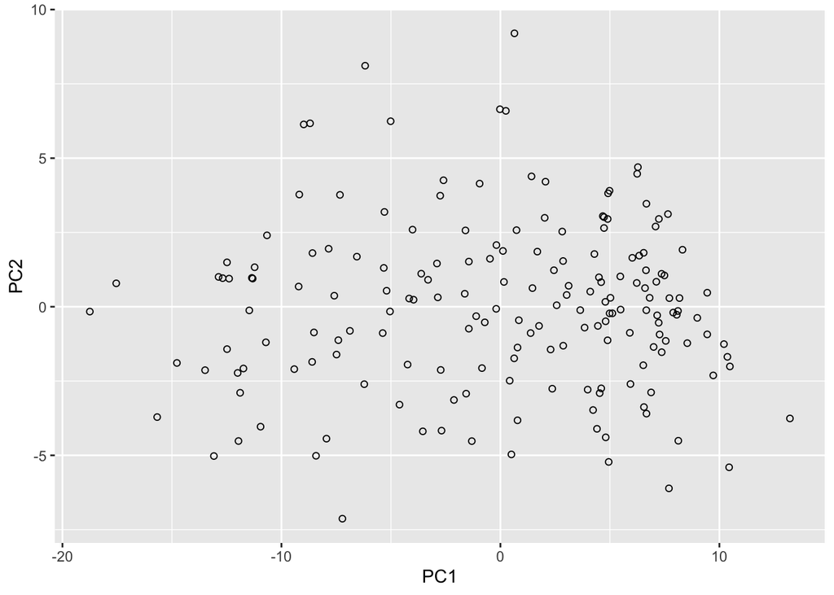

```r
## Read in the data
TBnanostring <- readRDS("TBnanostring.rds")

## Apply PCA
pca_out <- prcomp(TBnanostring[,-1])

## Make a dataframe with the results for plotting
pca_reduction <- as.data.frame(pca_out$x)
pca_reduction$Condition <- as.factor(TBnanostring$TB_Status)

## Change the shape of the points
pca_reduction %>% ggplot() +
  geom_point(aes(x=PC1, y=PC2), shape=1)
```

#### Step 7

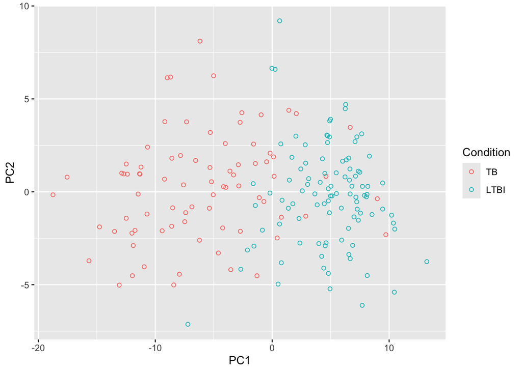

```r
## Read in the data
TBnanostring <- readRDS("TBnanostring.rds")

## Apply PCA
pca_out <- prcomp(TBnanostring[,-1])

## Make a dataframe with the results for plotting
pca_reduction <- as.data.frame(pca_out$x)
pca_reduction$Condition <- as.factor(TBnanostring$TB_Status)

## Change color of points (add a mapping aesthetic)
pca_reduction %>% ggplot() +
  geom_point(aes(x=PC1, y=PC2, color=Condition), shape=1)
```

#### Step 8

[figure not shown]

```r
## Read in the data
TBnanostring <- readRDS("TBnanostring.rds")

## Apply PCA
pca_out <- prcomp(TBnanostring[,-1])

## Make a dataframe with the results for plotting
pca_reduction <- as.data.frame(pca_out$x)
pca_reduction$Condition <- as.factor(TBnanostring$TB_Status)

## Add labels, title, and theme
pca_reduction %>% ggplot() +
  geom_point(aes(x=PC1, y=PC2, color=Condition), shape=1) +
  xlab("UMAP 1") + ylab("UMAP 2") + ggtitle("UMAP Plot") +
  theme(plot.title = element_text(hjust = 0.5))
```

### UMAP Example

Here is the final UMAP plot

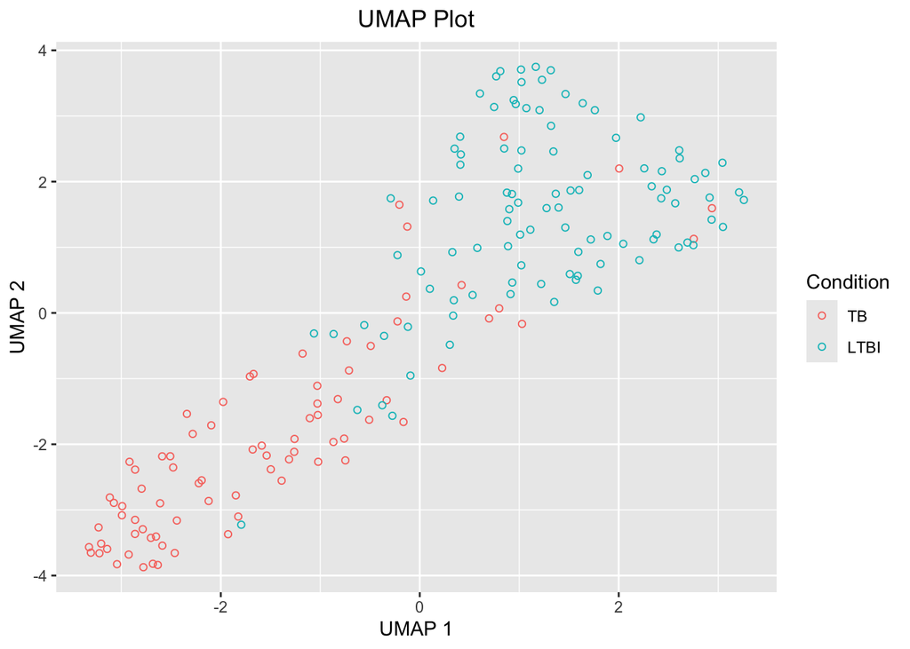

```r
## Read in data
TBnanostring <- readRDS("TBnanostring.rds")

## Apply UMAP reduction
set.seed(0)
library(umap)
umap_out <- umap(TBnanostring[,-1])

## Make dataframe for plotting in tidy format
umap_reduction <- as.data.frame(umap_out$layout)
umap_reduction$Condition <- as.factor(TBnanostring$TB_Status)

## Plot results with ggpplot
umap_reduction %>% ggplot() +
  geom_point(aes(x=V1, y=V2, color=Condition), shape=1) +
  xlab("UMAP 1") + ylab("UMAP 2") + ggtitle("UMAP Plot") +
  theme(plot.title = element_text(hjust = 0.5))
```

## Visualization and Dimension reduction

Now using an example dataset from: [Verma, et al., 2018](https://bmcinfectdis.biomedcentral.com/articles/10.1186/s12879-018-3127-4)

```r
## read in data
counts <- read.table("features_combined.txt",
  sep="\t", header=T, row.names=1)
meta_data <- read.table("meta_data.txt",
  sep="\t", header=T, row.names=1)
```

Using this dataset, please do the following:

1. Make a `SummarizedExperiment` object named `se_hivtb`.

2. Generate a log counts per million assay (hint: use `TBSignareProfiler::mkAssay()`).

3. Generate a Principal Components Analysis (PCA) plot for these data

4. Generate a Uniform Manifold Approximation and Projection (UMAP) plot for these data